# DATA 202 Homework 4

Adham Rishmawi

2022-10-28

1. because 27.2 is the average of all ages when gestation occurs so 27 is the mean of all those numbers not when the average age when bgestation occurs. b.Gestation is a period of time when the baby is developing so the statement insinuates that 27.2 is when birth occurs which is false assuming it is discussing average age when birth occurs.

```r
gestation_no_missing <- mosaicData::Gestation %>% filter(!is.na(age))
mean(~ age, data = gestation_no_missing)
```

```
[1] 27.25527
```

```r
set.rseed(123)
bootstrap <-
  do(1000) * df_stats(~ age, data = resample(gestation_no_missing),
                      mean, long_names = TRUE)
ci_stats <- cdata(~ mean_age, data = bootstrap, p = 0.95)
ci_stats
```

```
        lower    upper central.p
2.5% 26.94652 27.57628      0.95
```

Because for the 95% samples from the population, the coinfidence interval we compute will contain the true mean. Bootstrap resampling is when we pretend that our sample is the actually population and resampling from that fake population. The mean is a composition of the average of histogram values so it makes sense that the intervals falls in the middle to balance out the numbers that skew right and left

### Excercise 3

```r
model <- gf_point(wt ~ gestation, data = gestation_no_missing)
```

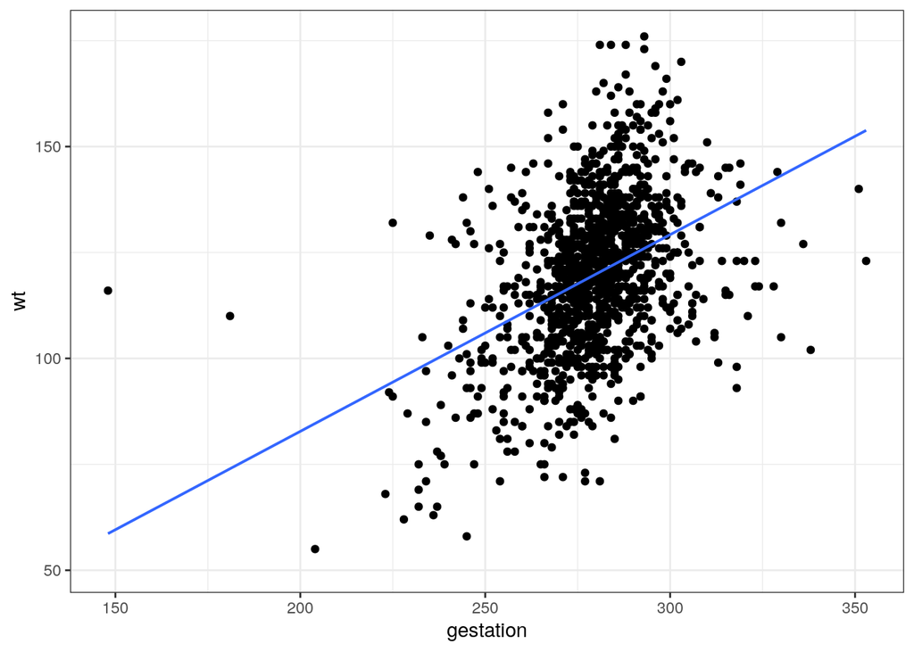

```r
slr <- lm(wt ~ gestation,
          data = gestation_no_missing)

gf_point(wt ~ gestation,
         data = gestation_no_missing) |>
  gf_lm()
```

```r
#model %>%
  #tidy(conf.int = TRUE) %>%
  #select(term, estimate, conf.low, conf.high)
```